# Graphics assignment

Yuliia Fedirko

26-04-2022

## Load Library

```r
library(tidyverse)
```

## Load Data

```r
NEI <- readRDS("summarySCC_PM25.rds")
SCC <- readRDS("Source_Classification_Code.rds")
```

## Inspect Data

```r
#Check structure of NEI
str(NEI)
```

```
## 'data.frame':    6497651 obs. of  6 variables:
##  $ fips     : chr  "09001" "09001" "09001" "09001" ...
##  $ SCC      : chr  "10100401" "10100404" "10100501" "10200401" ...
##  $ Pollutant: chr  "PM25-PRI" "PM25-PRI" "PM25-PRI" "PM25-PRI" ...
##  $ Emissions: num  15.714 234.178 0.128 2.036 0.388 ...
##  $ type     : chr  "POINT" "POINT" "POINT" "POINT" ...
##  $ year     : int  1999 1999 1999 1999 1999 1999 1999 1999 1999 1999 ...
```

```r
#Check column names of SCC
colnames(SCC)
```

```
##  [1] "SCC"                 "Data.Category"       "Short.Name"
##  [4] "EI.Sector"           "Option.Group"        "Option.Set"
##  [7] "SCC.Level.One"       "SCC.Level.Two"       "SCC.Level.Three"
## [10] "SCC.Level.Four"      "Map.To"              "Last.Inventory.Year"
## [13] "Created_Date"        "Revised_Date"        "Usage.Notes"
```

## Questions

1. Have total emissions from PM2.5 decreased in the United States from 1999 to 2008? Make a plot showing the **total** PM2.5 emission from all sources for each of the years 1999, 2002, 2005, and 2008.

```r
#Filter and aggregate data

total_by_year <- NEI %>%
  group_by(year) %>%
  summarize(emissions = sum(Emissions, na.rm = T))

total_by_year$emissions <- as.factor(total_by_year$emissions)
total_by_year$year <- as.factor(total_by_year$year)
```

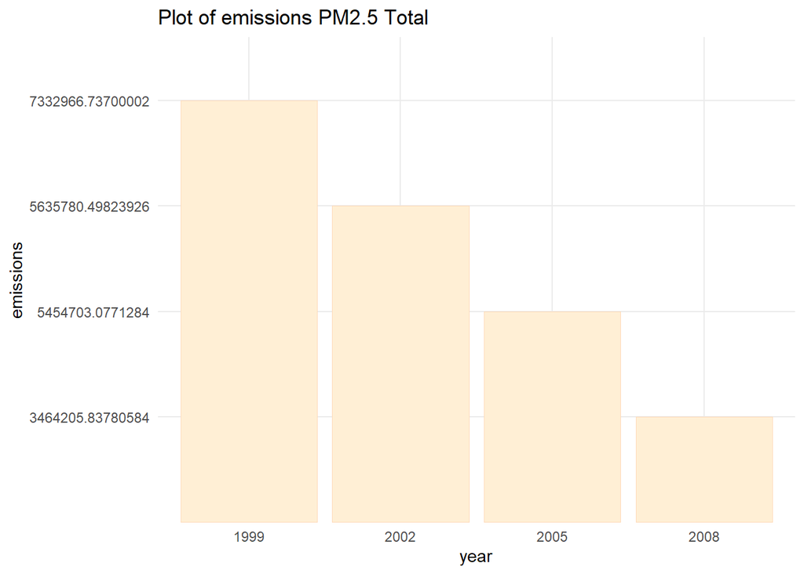

```r
# Basic barplot

p <- ggplot(total_by_year, aes(x=year, y=emissions)) +
  geom_bar(stat="identity", fill="PapayaWhip", col ="PeachPuff", size = .1)+
  theme_minimal() +
  ggtitle("Plot of emissions PM2.5 Total")

p
```

2. Have total emissions from PM2.5 decreased in the **Baltimore City**, Maryland (`fips == "24510"`) from 1999 to 2008?

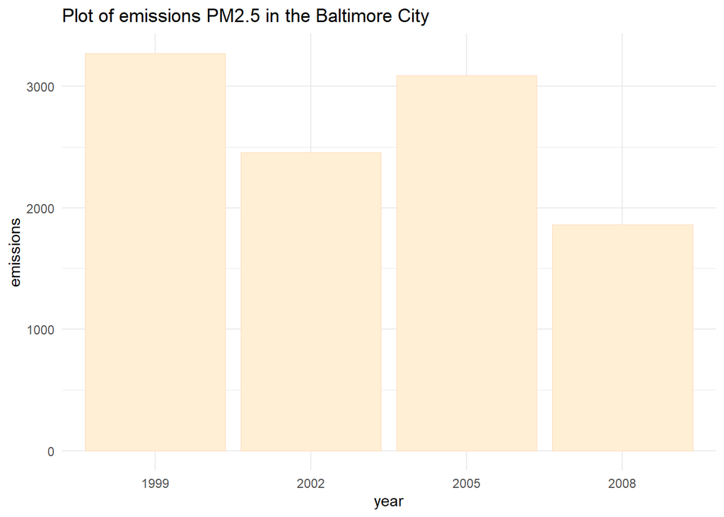

```r
baltimore_total <- NEI %>%
  filter(fips == 24510) %>%
  group_by(year) %>%
  summarize(emissions = sum(Emissions, na.rm = T))

baltimore_total$year <- as.factor(baltimore_total$year)

p <- ggplot(baltimore_total, aes(x=year, y=emissions)) +
  geom_bar(stat="identity", fill="PapayaWhip", col ="PeachPuff", size = .1)+
  theme_minimal() +
  ggtitle("Plot of emissions PM2.5 in the Baltimore City")

p
```

3. Of the four types of sources indicated by the `type` (point, nonpoint, onroad, nonroad) variable, which of these four sources have seen decreases in emissions from 1999–2008 for **Baltimore City**? Which have seen increases in emissions from 1999–2008?

```r
baltimore <- NEI %>%
  filter(fips == 24510)

baltimore_type <- aggregate(Emissions ~ year + type, baltimore, sum)
baltimore_type$year <- as.factor(baltimore_type$year)
```

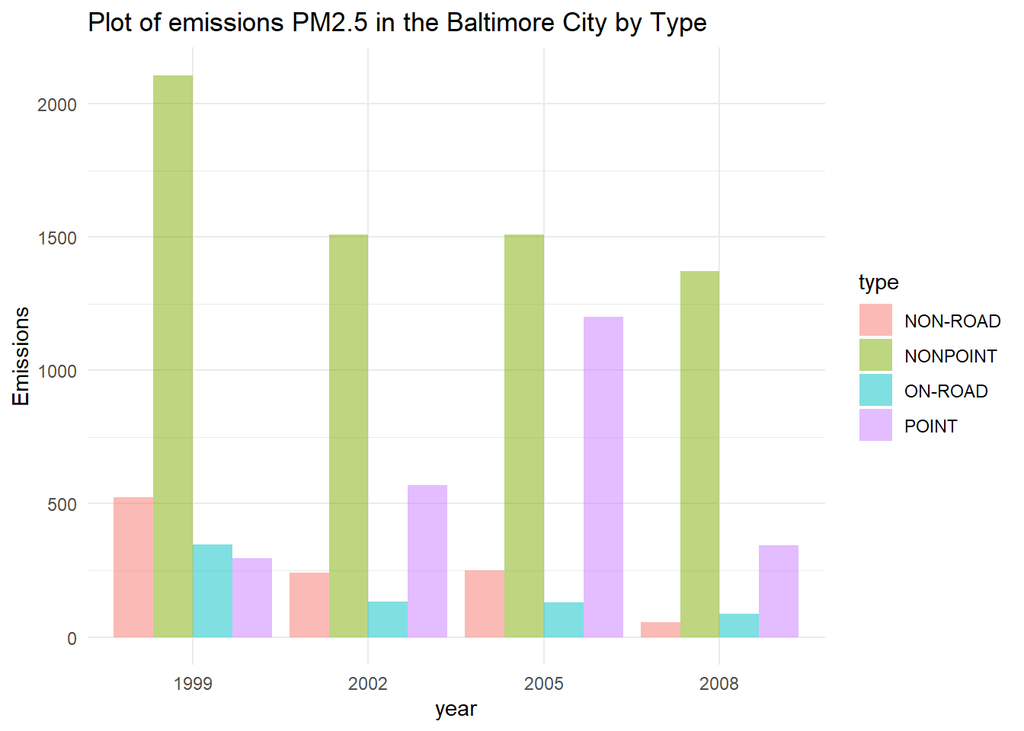

```r
p <- ggplot(baltimore_type, aes(x=year, y=Emissions, fill=type)) +
  geom_bar(alpha = 0.5, stat="identity", position=position_dodge()) +
  theme_minimal() +
  ggtitle("Plot of emissions PM2.5 in the Baltimore City by Type")

p
```

4. Across the United States, how have emissions from coal combustion-related sources changed from 1999–2008?

```r
#created a pattern to filter out coal-related sources
pattern <- 'coal'

#filter
coal_SCC <- SCC[grepl(pattern, SCC$Short.Name, ignore.case = T),]

# use this index vector to extract the rows
coal_related <-  NEI[NEI$SCC %in% coal_SCC$SCC,]
```

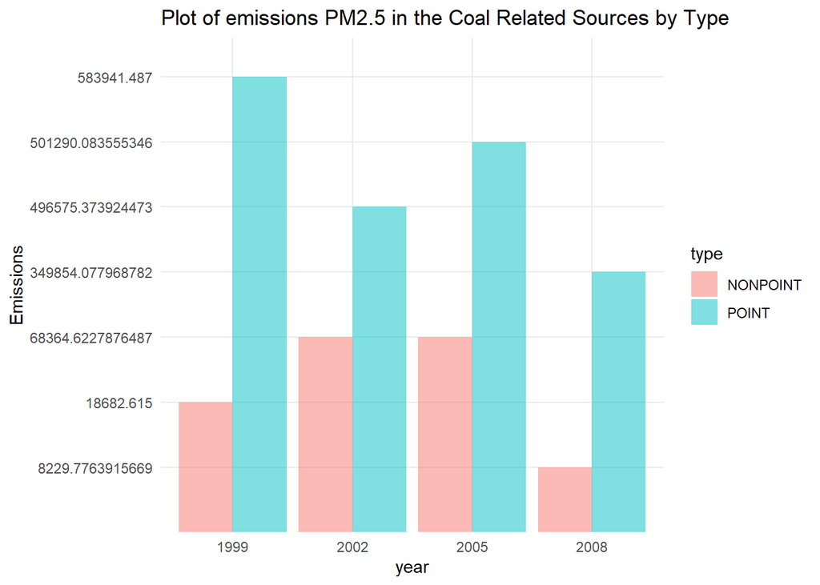

```r
coal_related_total <- aggregate(Emissions ~ year +type, coal_related, sum)
coal_related_total$year <- as.factor(coal_related_total$year)
coal_related_total$Emissions <- as.factor(coal_related_total$Emissions)


p <- ggplot(coal_related_total, aes(x=year, y=Emissions, fill = type)) +
  geom_bar(alpha = 0.5, stat="identity",position=position_dodge())+
  theme_minimal() +
  ggtitle("Plot of emissions PM2.5 in the Coal Related Sources by Type")

p
```

5. How have emissions from motor vehicle sources changed from 1999–2008 in **Baltimore City** (EI.Sector starts from “Mobile”)?

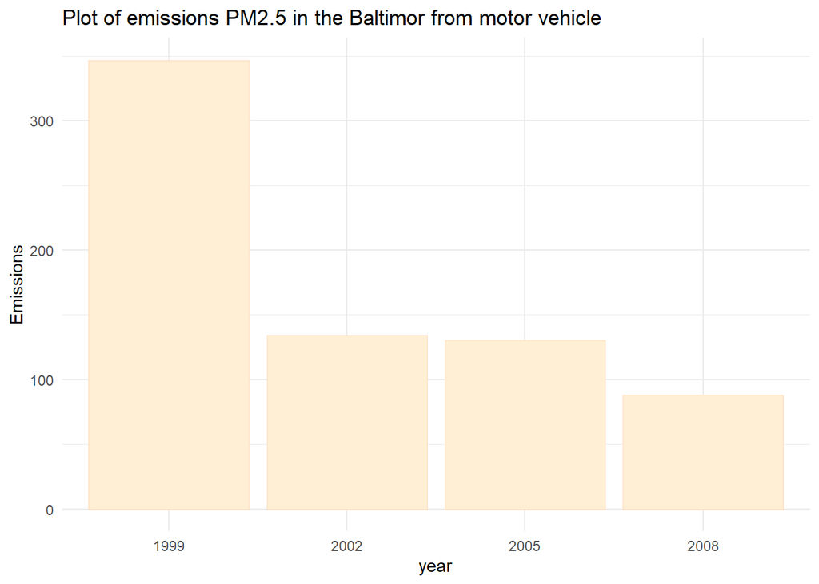

```r
baltimore_motor <- subset(NEI, NEI$fips == "24510" & NEI$type == "ON-ROAD")
baltimore_motor_total <- aggregate(Emissions ~ year, baltimore_motor, sum)
baltimore_motor_total$year <- as.factor(baltimore_motor_total$year)

p <- ggplot(baltimore_motor_total, aes(x=year, y=Emissions)) +
  geom_bar(stat="identity", fill="PapayaWhip", col ="PeachPuff", size = .1)+
  theme_minimal() +
  ggtitle("Plot of emissions PM2.5 in the Baltimor from motor vehicle")

p
```

6. Compare emissions from motor vehicle sources in Baltimore City with emissions from motor vehicle sources in **Los Angeles County**, California (`fips == "06037"`). Which city has seen greater changes over time in motor vehicle emissions?

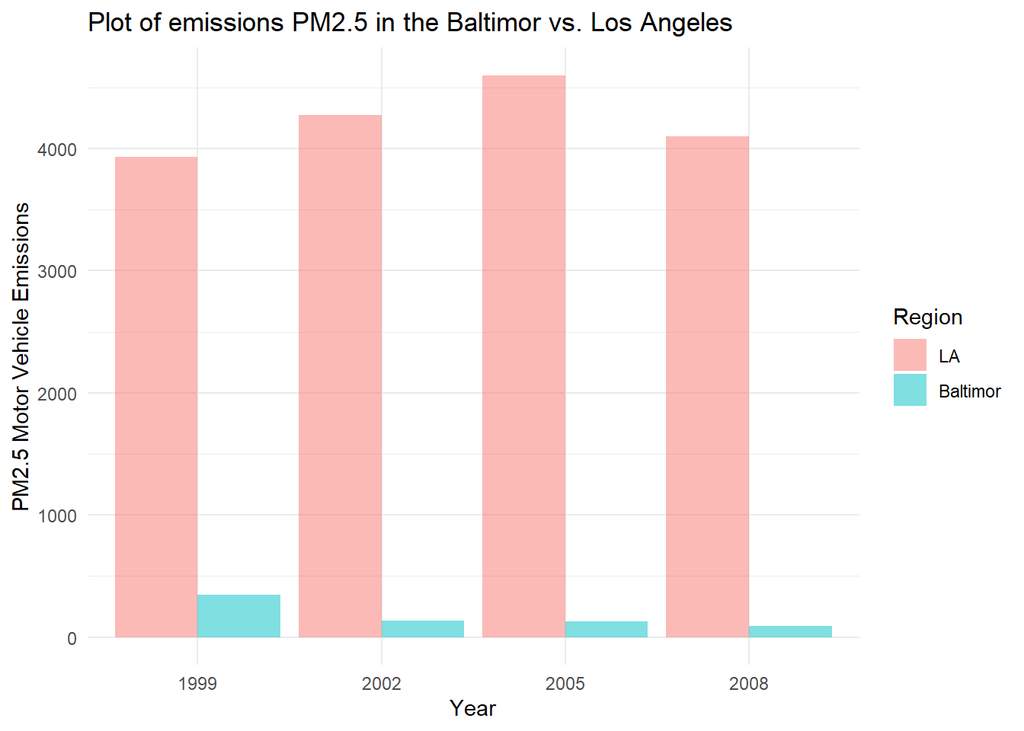

```r
baltimor_losangeles_motor <- subset(NEI, NEI$fips  %in% c("24510","06037") & NEI$type == "ON-ROAD")
baltimor_losangeles_motor_total <- aggregate(Emissions ~ year + fips, baltimor_losangeles_motor, sum)
baltimor_losangeles_motor_total$year <- as.factor(baltimor_losangeles_motor_total$year)


p <- ggplot(baltimor_losangeles_motor_total, aes(x=year, y=Emissions, fill = fips)) +
  geom_bar(alpha = 0.5, stat="identity",position=position_dodge())+
  theme_minimal() +
  labs(x = "Year", y = "PM2.5 Motor Vehicle Emissions") +
  ggtitle("Plot of emissions PM2.5 in the Baltimor vs. Los Angeles")


p + scale_fill_discrete(name = "Region", labels = c("LA", "Baltimor"))
```